# Practical Machine Learning Project

PK

12/03/2017

# Introduction

Using devices such as Jawbone Up, Nike FuelBand, and Fitbit it is now possible to collect a large amount of data about personal activity relatively inexpensively. These type of devices are part of the quantified self movement – a group of enthusiasts who take measurements about themselves regularly to improve their health, to find patterns in their behavior, or because they are tech geeks. One thing that people regularly do is quantify how much of a particular activity they do, but they rarely quantify how well they do it. In this project, your goal will be to use data from accelerometers on the belt, forearm, arm, and dumbell of 6 participants. They were asked to perform barbell lifts correctly and incorrectly in 5 different ways. More information is available from the website here: http://groupware.les.inf.puc-rio.br/har (see the section on the Weight Lifting Exercise Dataset).

# Data Processing

## Importing data

The training dataset has 19 622 observations and 160 variables. The testing data set contains 20 observations and same 160 variables as the training set. We are going to predict the outcome of the variable *classe* in the training set.

```r
# load the required packages
library(caret)
library(rattle)
library(rpart)
library(rpart.plot)
library(randomForest)
library(repmis)
```

```r
# The training data for this project are available here:
# https://d396qusza40orc.cloudfront.net/predmachlearn/pml-training.csv
# The test data are available here:
# https://d396qusza40orc.cloudfront.net/predmachlearn/pml-testing.csv
training <- read.csv("pml-training.csv", na.strings = c("NA", ""))
testing <- read.csv("pml-testing.csv", na.strings = c("NA", ""))
```

## Data cleaning

We remove columns (predictors) of the training set that contain any missing values.

```r
training <- training[, colSums(is.na(training)) == 0]
testing <- testing[, colSums(is.na(testing)) == 0]
```

We also remove the first seven columns since they are not helpful in our analysis.

```r
colnames(training[,1:7])
```

```
## [1] "X"                    "user_name"            "raw_timestamp_part_1"
## [4] "raw_timestamp_part_2" "cvtd_timestamp"       "new_window"
## [7] "num_window"
```

```r
training <- training[, -c(1:7)]
testing <- testing[, -c(1:7)]
```

The cleaned data sets now both have 53 columns with the same first 52 variables and the last variable *classe* and *problem_id* individually. The training data has 19 622 rows while testing data has 20 rows.

## Data splitting

In order to get out-of-sample errors, we split the cleaned training set into a training set (*train*, 70%) for prediction and a validation set (*valid*, 30%) to compute the out-of-sample errors.

```r
set.seed(12345)
inTrain <- createDataPartition(training$classe, p = 0.7, list = FALSE)
train <- training[inTrain, ]
valid <- training[-inTrain, ]
```

# Prediction Algorithms

We use *classification trees* and *random forests* to predict the outcome.

## Classification trees

We use 2-fold cross validation (faster than default setting of 10 in trainControl function) when implementing the algorithm.

```r
control <- trainControl(method = "cv", number = 2)
fit_rpart <- train(classe ~ ., data = train, method = "rpart", trControl = control)
print(fit_rpart)
```

```
## CART
##
## 13737 samples
##    52 predictor
##     5 classes: 'A', 'B', 'C', 'D', 'E'
##
## No pre-processing
## Resampling: Cross-Validated (2 fold)
## Summary of sample sizes: 6868, 6869
## Resampling results across tuning parameters:
##
##   cp          Accuracy   Kappa
##   0.03753433  0.5019291  0.34839424
##   0.05987862  0.3663099  0.12510987
##   0.11585800  0.3254684  0.06292229
##
## Accuracy was used to select the optimal model using  the largest value.
## The final value used for the model was cp = 0.03753433.
```

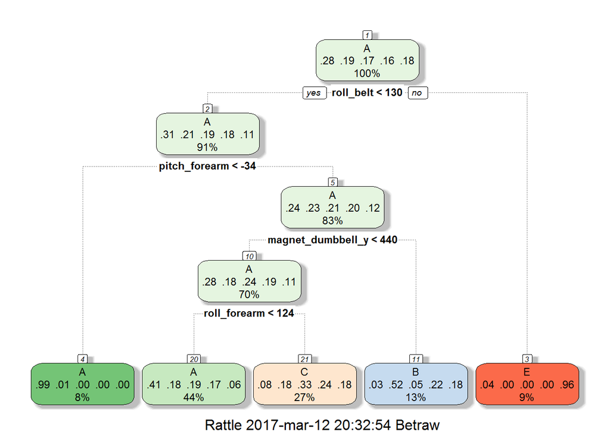

```r
fancyRpartPlot(fit_rpart$finalModel)
```

We predict outcomes using validation set.

```r
predict_rpart <- predict(fit_rpart, valid)
conf_rpart <- confusionMatrix(valid$classe, predict_rpart)
print(conf_rpart)
```

```
## Confusion Matrix and Statistics
##
##           Reference
## Prediction    A    B    C    D    E
##          A 1494   21  128    0   31
##          B  470  380  289    0    0
##          C  467   29  530    0    0
##          D  438  184  342    0    0
##          E  141  147  277    0  517
##
## Overall Statistics
##
##                Accuracy : 0.4963
##                  95% CI : (0.4835, 0.5092)
##     No Information Rate : 0.5115
##     P-Value [Acc > NIR] : 0.9902
##
##                   Kappa : 0.3425
##  Mcnemar's Test P-Value : NA
##
## Statistics by Class:
##
##                      Class: A Class: B Class: C Class: D Class: E
## Sensitivity            0.4963  0.49934  0.33844       NA  0.94343
## Specificity            0.9374  0.85187  0.88516   0.8362  0.89414
## Pos Pred Value         0.8925  0.33363  0.51657       NA  0.47782
## Neg Pred Value         0.6400  0.91972  0.78679       NA  0.99355
## Prevalence             0.5115  0.12931  0.26610   0.0000  0.09312
## Detection Rate         0.2539  0.06457  0.09006   0.0000  0.08785
## Detection Prevalence   0.2845  0.19354  0.17434   0.1638  0.18386
## Balanced Accuracy      0.7169  0.67561  0.61180       NA  0.91878
```

```r
accuracy_rpart <- conf_rpart$overall[1]
print(accuracy_rpart)
```

```
##  Accuracy
## 0.4963466
```

From the confusion matrix, the accuracy rate is around 0.5, and so the out-of-sample error rate is around 0.5. Using *classification tree* method does not predict the outcome classe very well.

## Random forest

We will try random forest method and try to increase the accuracy rate.

```r
rf_fit <- train(classe ~ ., data = train, method = "rf", trControl = control)
print(rf_fit)
```

```
## Random Forest
##
## 13737 samples
##    52 predictor
##     5 classes: 'A', 'B', 'C', 'D', 'E'
##
## No pre-processing
## Resampling: Cross-Validated (2 fold)
## Summary of sample sizes: 6868, 6869
## Resampling results across tuning parameters:
##
##   mtry  Accuracy   Kappa
##    2    0.9820194  0.9772509
##   27    0.9813643  0.9764240
##   52    0.9753951  0.9688747
##
## Accuracy was used to select the optimal model using  the largest value.
## The final value used for the model was mtry = 2.
```

We predict outcomes using validation set.

```r
rf_predict <- predict(rf_fit, valid)
rf_conf <- confusionMatrix(valid$classe, rf_predict)
print(rf_conf)
```

```
## Confusion Matrix and Statistics
##
##           Reference
## Prediction    A    B    C    D    E
##          A 1673    1    0    0    0
##          B   12 1121    6    0    0
##          C    0   15 1008    3    0
##          D    0    0   24  940    0
##          E    0    0    0    3 1079
##
## Overall Statistics
##
##                Accuracy : 0.9891
##                  95% CI : (0.9861, 0.9916)
##     No Information Rate : 0.2863
##     P-Value [Acc > NIR] : < 2.2e-16
##
##                   Kappa : 0.9862
##  Mcnemar's Test P-Value : NA
##
## Statistics by Class:
##
##                      Class: A Class: B Class: C Class: D Class: E
## Sensitivity            0.9929   0.9859   0.9711   0.9937   1.0000
## Specificity            0.9998   0.9962   0.9963   0.9951   0.9994
## Pos Pred Value         0.9994   0.9842   0.9825   0.9751   0.9972
## Neg Pred Value         0.9972   0.9966   0.9938   0.9988   1.0000
## Prevalence             0.2863   0.1932   0.1764   0.1607   0.1833
## Detection Rate         0.2843   0.1905   0.1713   0.1597   0.1833
## Detection Prevalence   0.2845   0.1935   0.1743   0.1638   0.1839
## Balanced Accuracy      0.9963   0.9911   0.9837   0.9944   0.9997
```

```r
rf_accuracy <- rf_conf$overall[1]
print(rf_accuracy)
```

```
##  Accuracy
## 0.9891249
```

# Results of Prediction on Testing Set

We use *random forest* to predict the outcome variable *classe* for the testing set.

```r
print(predict(rf_fit, testing))
```

```
##  [1] B A B A A E D B A A B C B A E E A B B B
## Levels: A B C D E
```